# Diamonds data sets

Fatimah Alamer

10/1/2021

**Introduction**

diamonds data sets is one of popular example data sets in R lets gets familiar with data set **first step** we have to install tidyvers package

```r
install.packages("tidyverse")
```

**second step**: Initialize package

```r
library(tidyverse)
```

Now, our diamonds data sets

```r
diamonds
```

```
## # A tibble: 53,940 x 10
##    carat cut       color clarity depth table price     x     y     z
##    <dbl> <ord>     <ord> <ord>   <dbl> <dbl> <int> <dbl> <dbl> <dbl>
##  1  0.23 Ideal     E     SI2      61.5    55   326  3.95  3.98  2.43
##  2  0.21 Premium   E     SI1      59.8    61   326  3.89  3.84  2.31
##  3  0.23 Good      E     VS1      56.9    65   327  4.05  4.07  2.31
##  4  0.29 Premium   I     VS2      62.4    58   334  4.2   4.23  2.63
##  5  0.31 Good      J     SI2      63.3    58   335  4.34  4.35  2.75
##  6  0.24 Very Good J     VVS2     62.8    57   336  3.94  3.96  2.48
##  7  0.24 Very Good I     VVS1     62.3    57   336  3.95  3.98  2.47
##  8  0.26 Very Good H     SI1      61.9    55   337  4.07  4.11  2.53
##  9  0.22 Fair      E     VS2      65.1    61   337  3.87  3.78  2.49
## 10  0.23 Very Good H     VS1      59.4    61   338  4     4.05  2.39
## # ... with 53,930 more rows
```

Now, lets gets familiar with data, you may think to use summary, or we can use glimpse function from tidyvers package, you can now see the difference

```r
summary(diamonds)
```

```
##      carat               cut        color        clarity          depth
##  Min.   :0.2000   Fair     : 1610   D: 6775   SI1    :13065   Min.   :43.00
##  1st Qu.:0.4000   Good     : 4906   E: 9797   VS2    :12258   1st Qu.:61.00
##  Median :0.7000   Very Good:12082   F: 9542   SI2    : 9194   Median :61.80
##  Mean   :0.7979   Premium  :13791   G:11292   VS1    : 8171   Mean   :61.75
##  3rd Qu.:1.0400   Ideal    :21551   H: 8304   VVS2   : 5066   3rd Qu.:62.50
##  Max.   :5.0100                     I: 5422   VVS1   : 3655   Max.   :79.00
##                                     J: 2808   (Other): 2531
##      table           price             x                y
##  Min.   :43.00   Min.   :  326   Min.   : 0.000   Min.   : 0.000
##  1st Qu.:56.00   1st Qu.:  950   1st Qu.: 4.710   1st Qu.: 4.720
##  Median :57.00   Median : 2401   Median : 5.700   Median : 5.710
##  Mean   :57.46   Mean   : 3933   Mean   : 5.731   Mean   : 5.735
##  3rd Qu.:59.00   3rd Qu.: 5324   3rd Qu.: 6.540   3rd Qu.: 6.540
##  Max.   :95.00   Max.   :18823   Max.   :10.740   Max.   :58.900
##
##        z
##  Min.   : 0.000
##  1st Qu.: 2.910
##  Median : 3.530
##  Mean   : 3.539
##  3rd Qu.: 4.040
##  Max.   :31.800
##
```

```r
glimpse(diamonds)
```

```
## Rows: 53,940
## Columns: 10
## $ carat   <dbl> 0.23, 0.21, 0.23, 0.29, 0.31, 0.24, 0.24, 0.26, 0.22, 0.23, 0.~
## $ cut     <ord> Ideal, Premium, Good, Premium, Good, Very Good, Very Good, Ver~
## $ color   <ord> E, E, E, I, J, J, I, H, E, H, J, J, F, J, E, E, I, J, J, J, I,~
## $ clarity <ord> SI2, SI1, VS1, VS2, SI2, VVS2, VVS1, SI1, VS2, VS1, SI1, VS1, ~
## $ depth   <dbl> 61.5, 59.8, 56.9, 62.4, 63.3, 62.8, 62.3, 61.9, 65.1, 59.4, 64~
## $ table   <dbl> 55, 61, 65, 58, 58, 57, 57, 55, 61, 61, 55, 56, 61, 54, 62, 58~
## $ price   <int> 326, 326, 327, 334, 335, 336, 336, 337, 337, 338, 339, 340, 34~
## $ x       <dbl> 3.95, 3.89, 4.05, 4.20, 4.34, 3.94, 3.95, 4.07, 3.87, 4.00, 4.~
## $ y       <dbl> 3.98, 3.84, 4.07, 4.23, 4.35, 3.96, 3.98, 4.11, 3.78, 4.05, 4.~
## $ z       <dbl> 2.43, 2.31, 2.31, 2.63, 2.75, 2.48, 2.47, 2.53, 2.49, 2.39, 2.~
```

Now, we know some information regarding the data: +There are 53,940 round-cut diamonds,that is exactly the number of rows! +There are 10 variables:cut, color, & clarity,carat, depth, table, x, y, z, price

**1-data transformation with dplyr** now,we want to know the price regarding for each clarity type:

```r
diamonds%>%
  group_by(clarity ) %>%
  summarise(avg = mean(price),
            mimum= min(price),
            max= max(price),
            stdev = sd(price))
```

```
## # A tibble: 8 x 5
##   clarity   avg mimum   max stdev
##   <ord>   <dbl> <int> <int> <dbl>
## 1 I1      3924.   345 18531 2807.
## 2 SI2     5063.   326 18804 4260.
## 3 SI1     3996.   326 18818 3799.
## 4 VS2     3925.   334 18823 4042.
## 5 VS1     3839.   327 18795 4012.
## 6 VVS2    3284.   336 18768 3822.
## 7 VVS1    2523.   336 18777 3335.
## 8 IF      2865.   369 18806 3920.
```

for more usefull information, see [dplyr cheat sheet](https://nyu-cdsc.github.io/learningr/assets/data-transformation.pdf)

**2-Data tidying with tidyr** lets make our data tidy.

```r
diamonds%>%

  pivot_longer(c(x,y,z), names_to = "dimension", values_to = "value") -> diamonds_tidy
```

after making tidy data long , we have 161820 observation ! increasing number of observation will makes it easier to reproduce analyses because they are more easy to understand, update, and reuse. for more useful information, see [tidyer cheat sheet](https://github.com/rstudio/cheatsheets/blob/master/tidyr.pdf')

**3-data vizulization with ggplot2** lets have the first ggplot:

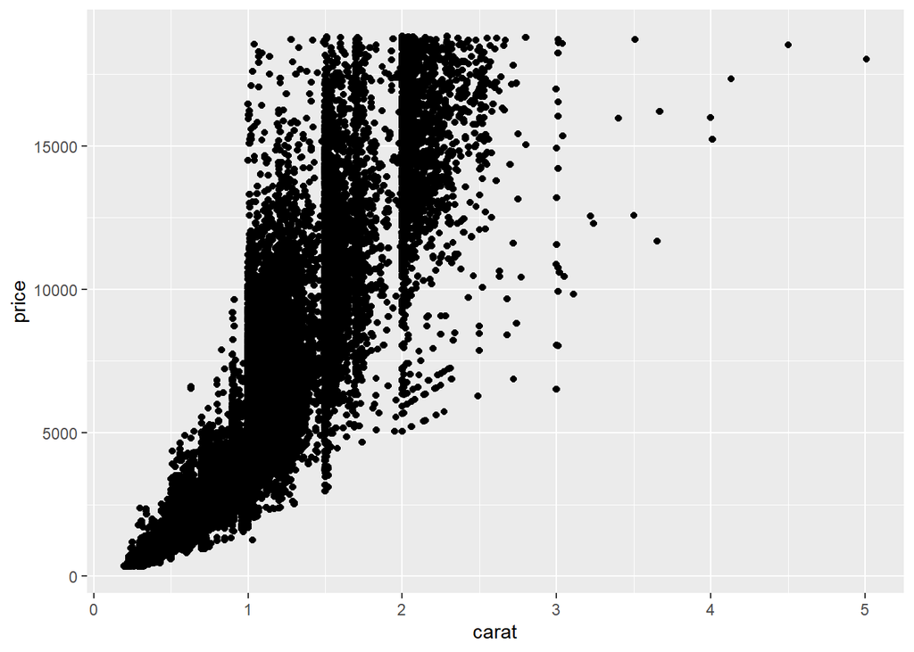

```r
ggplot(diamonds_tidy, aes(carat, price)) + geom_point()+
geom_point(shape = 16, alpha = 0.5, position = "jitter")
```

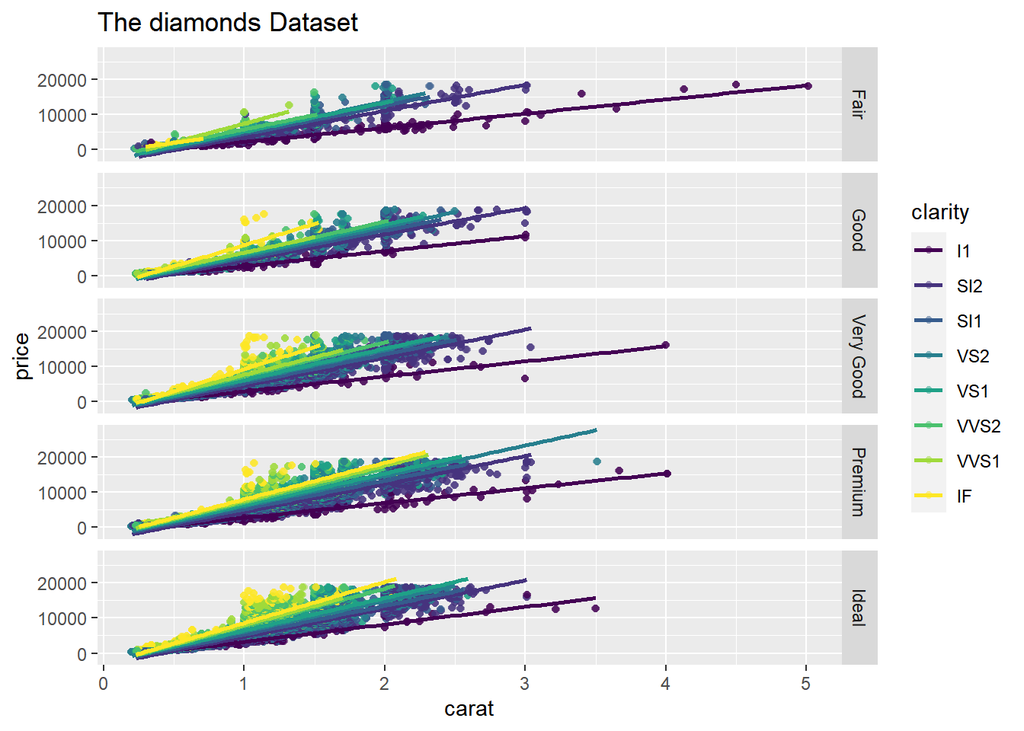

```r
ggplot(diamonds_tidy, aes(carat, price,color = clarity)) +
geom_point(shape = 16, alpha = 0.5, position = "jitter")+
      geom_smooth(method=lm, se=FALSE)+
facet_grid(cut~.)+
 labs(x = "carat",
       y = "price",
       title = "The diamonds Dataset",
       color = "clarity")
```

for more useful information, see [ggplot2 cheat sheet](https://nyu-cdsc.github.io/learningr/assets/data-visualization-2.1.pdf)

**4-Table**:the largest 20 diamonds in the `diamonds` dataset

```r
library(knitr)
diamonds %>%
  arrange(desc(carat)) %>%
  slice(1:20) %>%
  select(carat, cut, color, clarity) %>%
  knitr::kable(
    caption = "The largest 20 diamonds in the `diamonds` dataset."
  )
```

The largest 20 diamonds in the `diamonds` dataset.

| carat | cut | color | clarity |
| --- | --- | --- | --- |
| 5.01 | Fair | J | I1 |
| 4.50 | Fair | J | I1 |
| 4.13 | Fair | H | I1 |
| 4.01 | Premium | I | I1 |
| 4.01 | Premium | J | I1 |
| 4.00 | Very Good | I | I1 |
| 3.67 | Premium | I | I1 |
| 3.65 | Fair | H | I1 |
| 3.51 | Premium | J | VS2 |
| 3.50 | Ideal | H | I1 |
| 3.40 | Fair | D | I1 |
| 3.24 | Premium | H | I1 |
| 3.22 | Ideal | I | I1 |
| 3.11 | Fair | J | I1 |
| 3.05 | Premium | E | I1 |
| 3.04 | Very Good | I | SI2 |
| 3.04 | Premium | I | SI2 |
| 3.02 | Fair | I | I1 |
| 3.01 | Premium | I | I1 |
| 3.01 | Premium | F | I1 |